# logistic regression

caojilin

5/11/2019

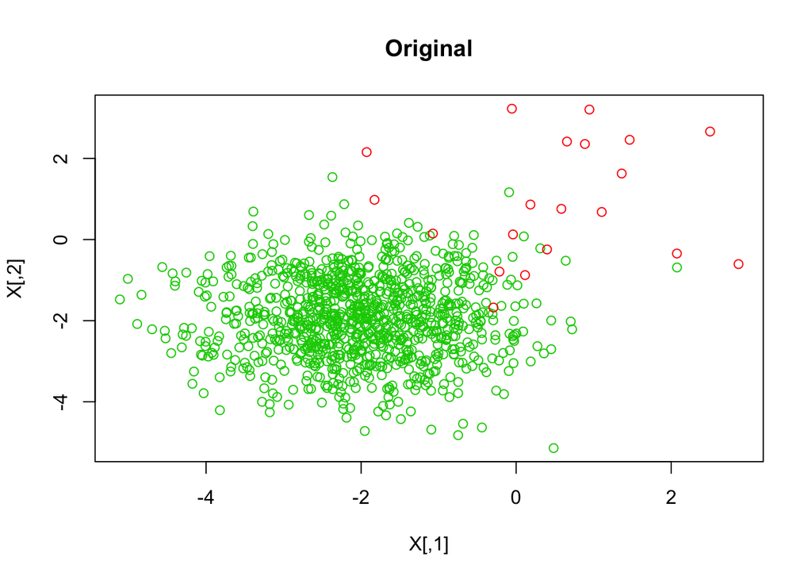

```r
# multivariate normal data generating
# first experiment, very imbalenced two classes datasets
set.seed(2)

num_class1 = 1000
num_class2 = 20
X = matrix(rep(0, (num_class1 + num_class2)*2), ncol=2)
mu1  = c(-2,-2)
sigma1 = diag(2)
mu2  = c(1,1)
sigma2 = matrix(c(1,0,0,2) ,2,2, byrow = T)

for (i in 1:num_class1) {
    obsev = mvrnorm(1, mu1, sigma1)
    X[i,1] = obsev[1]
    X[i,2] = obsev[2]
}
for (i in (num_class1+1):(num_class1+num_class2)) {
  obsev = mvrnorm(1, mu2, sigma2)
  X[i,1] = obsev[1]
  X[i,2] = obsev[2]
}

label = c(rep(1,num_class1), rep(0,num_class2))

plot(X, col=label+2, main = "Original")
```

```r
logistic.model = glm(label ~ X , family = "binomial")
summary(logistic.model)
```

```
##
## Call:
## glm(formula = label ~ X, family = "binomial")
##
## Deviance Residuals:
##      Min        1Q    Median        3Q       Max
## -3.13907   0.00776   0.02143   0.05458   1.91459
##
## Coefficients:
##             Estimate Std. Error z value Pr(>|z|)
## (Intercept)   0.7480     0.4652   1.608    0.108
## X1           -1.6758     0.3665  -4.572 4.82e-06 ***
## X2           -2.1960     0.4685  -4.687 2.77e-06 ***
## ---
## Signif. codes:  0 '***' 0.001 '**' 0.01 '*' 0.05 '.' 0.1 ' ' 1
##
## (Dispersion parameter for binomial family taken to be 1)
##
##     Null deviance: 196.878  on 1019  degrees of freedom
## Residual deviance:  52.963  on 1017  degrees of freedom
## AIC: 58.963
##
## Number of Fisher Scoring iterations: 9
```

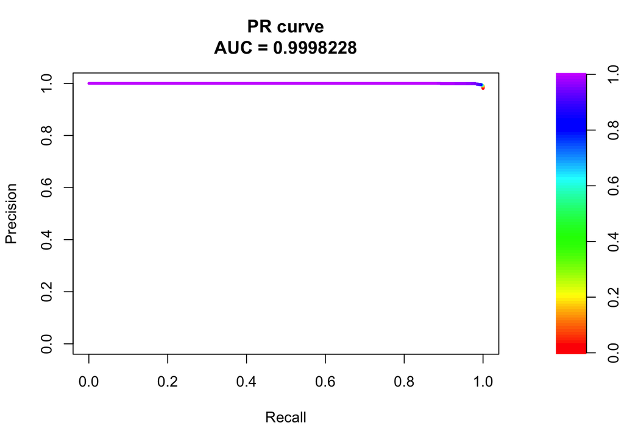

```r
y_hat_prob = predict(logistic.model, data.frame(X), type = "response")
scores.class0 = y_hat_prob[label == 1]
scores.class1 = y_hat_prob[label == 0]
pr1 = pr.curve(scores.class0, scores.class1, curve = T)
plot(pr1)
```

```r
y_hat = y_hat_prob > 0.5
mean(y_hat == label)
```

```
## [1] 0.9911765
```

traning accuracy, as you can see, pretty high. However, it doesn’t mean anything, because even a trivial classifier can get pretty high accurcy Why do we care about this? Say one of our class is for rare events, such as disease Among polutation, the percentage for ppl have disease is very low, for example, 1% You can’t just say, well, my classifier have a 99% accuracy for detecting disease. Instead of accuracy(which is one of the many metrics), we care more about recall hence sacrifice the precision. Why? we have to make sure we can identify (almost) all of potential ppl with disease. It’s gonna harm less to have more false positive instead of more false negative. The way we do this is to adjust the threshold to countrol the recall.

```r
y_hat[which(y_hat == FALSE)] <- 0
y_hat[which(y_hat == TRUE)] <- 1
confusionMatrix(as.factor(y_hat), as.factor(label))
```

```
## Confusion Matrix and Statistics
##
##           Reference
## Prediction   0   1
##          0  13   2
##          1   7 998
##
##                Accuracy : 0.9912
##                  95% CI : (0.9833, 0.996)
##     No Information Rate : 0.9804
##     P-Value [Acc > NIR] : 0.004687
##
##                   Kappa : 0.7385
##
##  Mcnemar's Test P-Value : 0.182422
##
##             Sensitivity : 0.65000
##             Specificity : 0.99800
##          Pos Pred Value : 0.86667
##          Neg Pred Value : 0.99303
##              Prevalence : 0.01961
##          Detection Rate : 0.01275
##    Detection Prevalence : 0.01471
##       Balanced Accuracy : 0.82400
##
##        'Positive' Class : 0
##
```

In this case, 0 means sick people (positive) , 1 means people are healthy (negative).

We have total 20 diseased people  
recall = 0.65000  
among all sick people, we only find 65% of them, which means  
we missed 35% of sick people, this is really bad.  
precision = 13/15 = 0.8666667, among people whom we think are sick, 86% of them  
are truly sick.

True positive: Sick people correctly identified as sick  
False positive: Healthy people incorrectly identified as sick  
True negative: Healthy people correctly identified as healthy  
False negative: Sick people incorrectly identified as healthy

hypothesis testing: is this person healthy? The null hypothesis is: this person is healthy  
The alternative is: this person is sick

Type-I error: when the null hypothesis is true, we reject the null  
The probability of a Type-I error is called the significance level, usually denoted by $\alpha$. This is the threshold we can pick and control. It can be 0.05 or 0.01. Then p-value is the probability that a statistic summary is greater than or equal to the observed, under the null is true. We don’t have test statistic yet.  
Type-II error: when the null hyopthesis is false, we accept the null

Now, let’s try a different theshold

```r
# now our threshold become more strick
y_hat = y_hat_prob > 0.95
mean(y_hat == label)
```

```
## [1] 0.9794118
```

```r
y_hat[which(y_hat == FALSE)] <- 0
y_hat[which(y_hat == TRUE)] <- 1
confusionMatrix(as.factor(y_hat), as.factor(label))
```

```
## Confusion Matrix and Statistics
##
##           Reference
## Prediction   0   1
##          0  19  20
##          1   1 980
##
##                Accuracy : 0.9794
##                  95% CI : (0.9687, 0.9872)
##     No Information Rate : 0.9804
##     P-Value [Acc > NIR] : 0.6445
##
##                   Kappa : 0.6346
##
##  Mcnemar's Test P-Value : 8.568e-05
##
##             Sensitivity : 0.95000
##             Specificity : 0.98000
##          Pos Pred Value : 0.48718
##          Neg Pred Value : 0.99898
##              Prevalence : 0.01961
##          Detection Rate : 0.01863
##    Detection Prevalence : 0.03824
##       Balanced Accuracy : 0.96500
##
##        'Positive' Class : 0
##
```

Now, our accuracy has decreased from 0.9911765 to 0.9794118  
recall = 0.95000, among all sick people, we identified 0.95 of them.  
precision = 0.48718, among people whom what we think are sick, only half of them are really sick  
For healthy people who are identified as sick, we can conduct more medical test. However if we missed some potential sick people, it’s hard to get them back, and their disease will get even worse as days go by.  
We sacrificed precion in exchange of recall.

Now, let’s see the effect of sample size

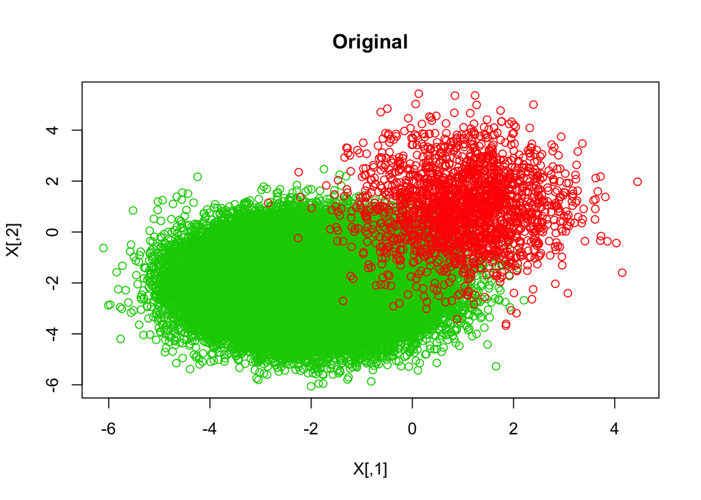

```r
set.seed(2)

num_class1 = 100000
num_class2 = 2000
X = matrix(rep(0, (num_class1 + num_class2)*2), ncol=2)
mu1  = c(-2,-2)
sigma1 = diag(2)
mu2  = c(1,1)
sigma2 = matrix(c(1,0,0,2) ,2,2, byrow = T)

for (i in 1:num_class1) {
    obsev = mvrnorm(1, mu1, sigma1)
    X[i,1] = obsev[1]
    X[i,2] = obsev[2]
}
for (i in (num_class1+1):(num_class1+num_class2)) {
  obsev = mvrnorm(1, mu2, sigma2)
  X[i,1] = obsev[1]
  X[i,2] = obsev[2]
}

label = c(rep(1,num_class1), rep(0,num_class2))

plot(X, col=label+2, main = "Original")
```

```r
logistic.model = glm(label ~ X , family = "binomial")
summary(logistic.model)
```

```
##
## Call:
## glm(formula = label ~ X, family = "binomial")
##
## Deviance Residuals:
##     Min       1Q   Median       3Q      Max
## -4.6695   0.0014   0.0051   0.0180   2.9227
##
## Coefficients:
##             Estimate Std. Error z value Pr(>|z|)
## (Intercept)  0.83972    0.05698   14.74   <2e-16 ***
## X1          -2.90964    0.07275  -40.00   <2e-16 ***
## X2          -2.24953    0.06125  -36.73   <2e-16 ***
## ---
## Signif. codes:  0 '***' 0.001 '**' 0.01 '*' 0.05 '.' 0.1 ' ' 1
##
## (Dispersion parameter for binomial family taken to be 1)
##
##     Null deviance: 19687.8  on 101999  degrees of freedom
## Residual deviance:  2724.2  on 101997  degrees of freedom
## AIC: 2730.2
##
## Number of Fisher Scoring iterations: 11
```

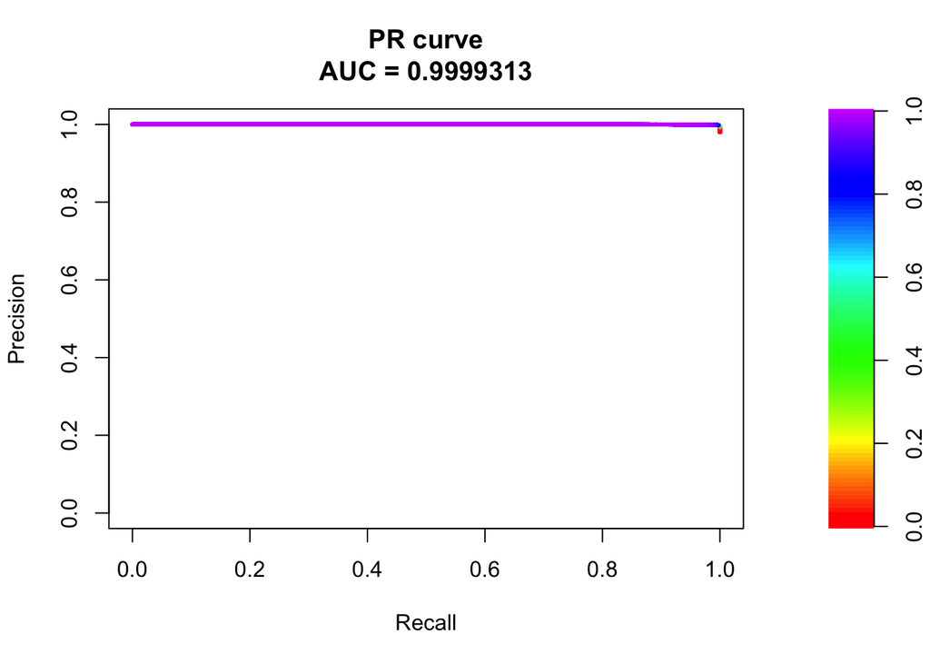

```r
y_hat_prob = predict(logistic.model, data.frame(X), type = "response")
scores.class0 = y_hat_prob[label == 1]
scores.class1 = y_hat_prob[label == 0]
pr1 = pr.curve(scores.class0, scores.class1, curve = T)
plot(pr1)
```

```r
y_hat = y_hat_prob > 0.5
mean(y_hat == label)
```

```
## [1] 0.9956765
```

```r
y_hat[which(y_hat == FALSE)] <- 0
y_hat[which(y_hat == TRUE)] <- 1
confusionMatrix(as.factor(y_hat), as.factor(label))
```

```
## Confusion Matrix and Statistics
##
##           Reference
## Prediction     0     1
##          0  1688   129
##          1   312 99871
##
##                Accuracy : 0.9957
##                  95% CI : (0.9953, 0.9961)
##     No Information Rate : 0.9804
##     P-Value [Acc > NIR] : < 2.2e-16
##
##                   Kappa : 0.8823
##
##  Mcnemar's Test P-Value : < 2.2e-16
##
##             Sensitivity : 0.84400
##             Specificity : 0.99871
##          Pos Pred Value : 0.92900
##          Neg Pred Value : 0.99689
##              Prevalence : 0.01961
##          Detection Rate : 0.01655
##    Detection Prevalence : 0.01781
##       Balanced Accuracy : 0.92135
##
##        'Positive' Class : 0
##
```